# State MSM Profile: **Washington**

### Background & Methods

In 2015-2016, researchers at Emory University partnered with colleagues at the Centers for Disease Control and Prevention (CDC) to develop methods to estimate the number of men who have sex with men (MSM) residing in each county in the United States. Using population and housing data from the [American Community Survey](https://www.census.gov/programs-surveys/acs/) and estimates from two peer-reviewed publications ([Oster et al., 2015](http://www.ncbi.nlm.nih.gov/pubmed/26115985) & [Purcell et al., 2012](http://www.ncbi.nlm.nih.gov/pubmed/23049658)), they derived an indirect estimate of MSM population sizes that took into account both the urbanicity of the county as well as its density of households with a male householder and a male same-sex partner.

The full methodology is published in the *Journal of Medical Internet Research - Public Health and Surveillance*:

> [Grey JA, Bernstein KT, Sullivan PS, Purcell DW, Chesson HW, Gift TL, Rosenberg ES. Estimating the population sizes of men who have sex with men in US states and counties using data from the American Community Survey. JMIR Public Health Surveill 2016;2(1):e14. DOI: 10.2196/publichealth.5365](http://publichealth.jmir.org/2016/1/e14/)

### Overview of MSM in Washington

An estimated **111,960** men who have sex with men (MSM) resided in Washington in 2013, representing 2.5% of the 4,503,084 MSM in the United States. Of the 2,590,196 adult men of Washington, 4.3% had had sex with another man in the past 5 years, which was greater than the overall percentage of adult men in the United States who were MSM (3.9%).

Most MSM in Washington resided in central counties of large metropolitan areas (55.2%). Including both central and fringe counties, 79.8% resided in a large metropolitan area.

##### **Percentage of MSM by urbanicity, United States and Washington, 2013**

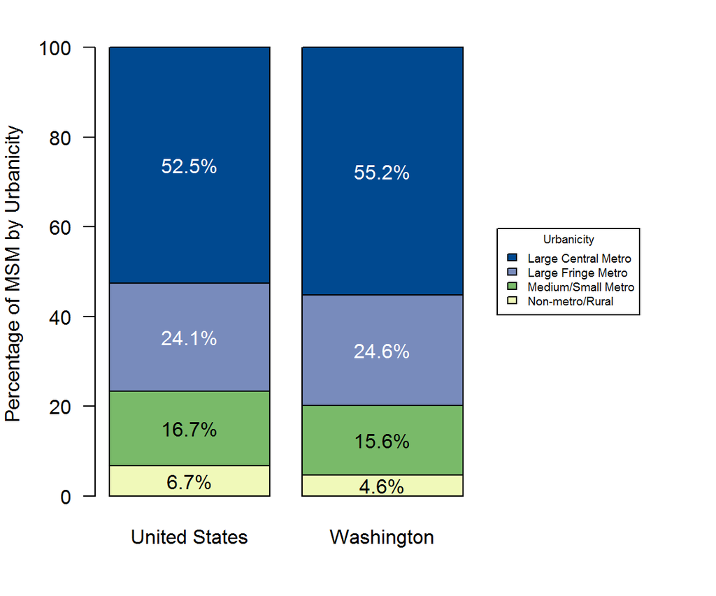

### MSM in Washington Counties

Among counties or county-equivalent areas in Washington, King County had the largest population of MSM at 61,751, representing 55.2% of all MSM in the state. King County also had the highest percentage of MSM among adult men in Washington at 8.0%. This was greater than the percentage for Washington as a whole, which was 4.3% of adult men.

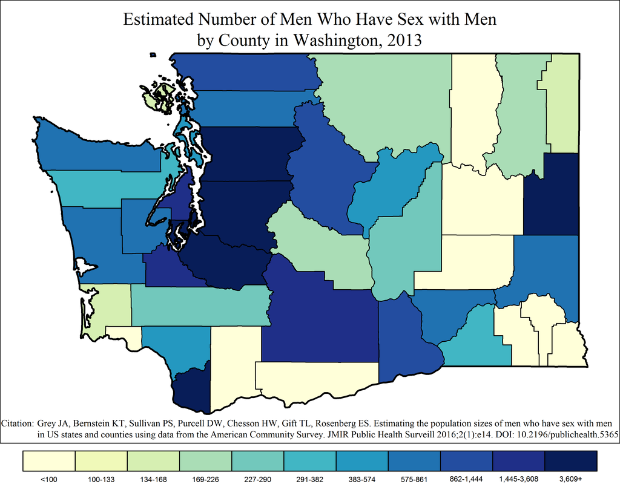

Note: Range cutpoints for the map are based on the distribution of MSM among all counties in the United States.

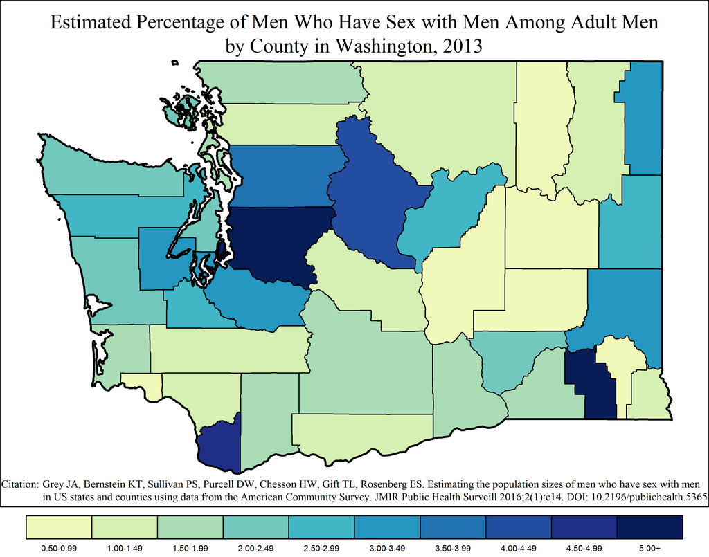

### MSM in Washington Metropolitan Statistical Areas

#### Seattle-Tacoma-Bellevue Metropolitan Statistical Area

The Seattle-Tacoma-Bellevue MSA had the largest metropolitan population of MSM in Washington at 82,002, or 73.2% of all MSM in the state. Of the 1,342,052 adult men in Seattle-Tacoma-Bellevue, an estimated 6.1% were MSM.

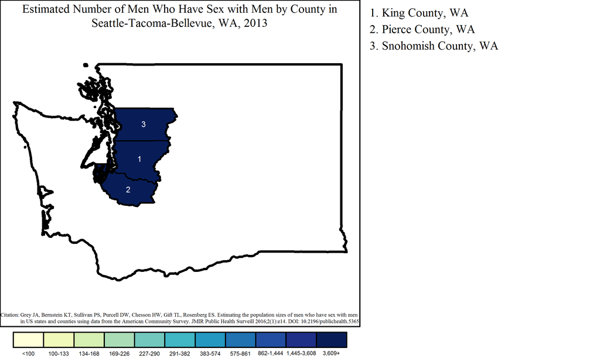

Note: Range cutpoints for the map are based on the distribution of MSM among all counties in the United States.

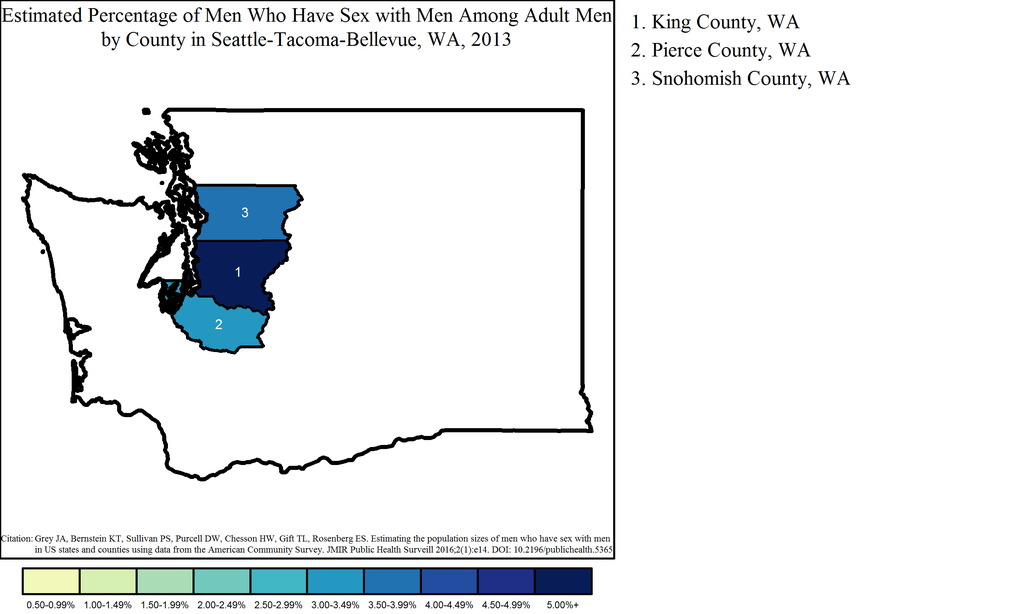

#### Portland-Vancouver-Hillsboro Metropolitan Statistical Area

The Portland-Vancouver-Hillsboro MSA overlaps two states: Oregon and Washington. The Washington portion of the MSA had 7,313 MSM, or 6.5% of all MSM in the state and 13.8% of the 52,966 MSM in the MSA. Of 160,232 adult men in the Washington part of Portland-Vancouver-Hillsboro, 4.6% were MSM. This was less than the overall percentage of MSM among adult men in the MSA, which was 6.3% of adult men (52,966 out of 846,640).

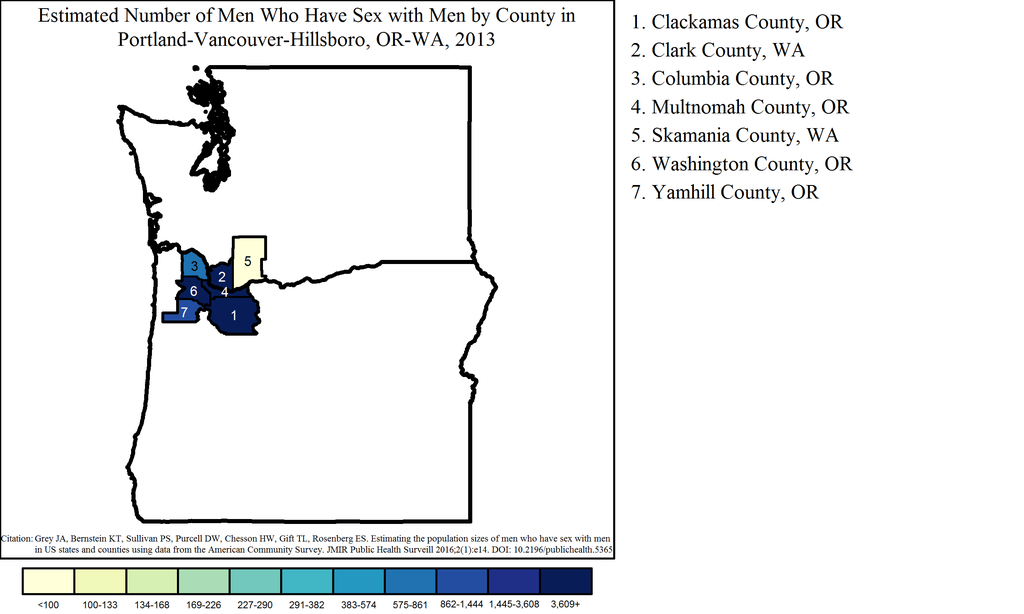

Note: Range cutpoints for the map are based on the distribution of MSM among all counties in the United States.

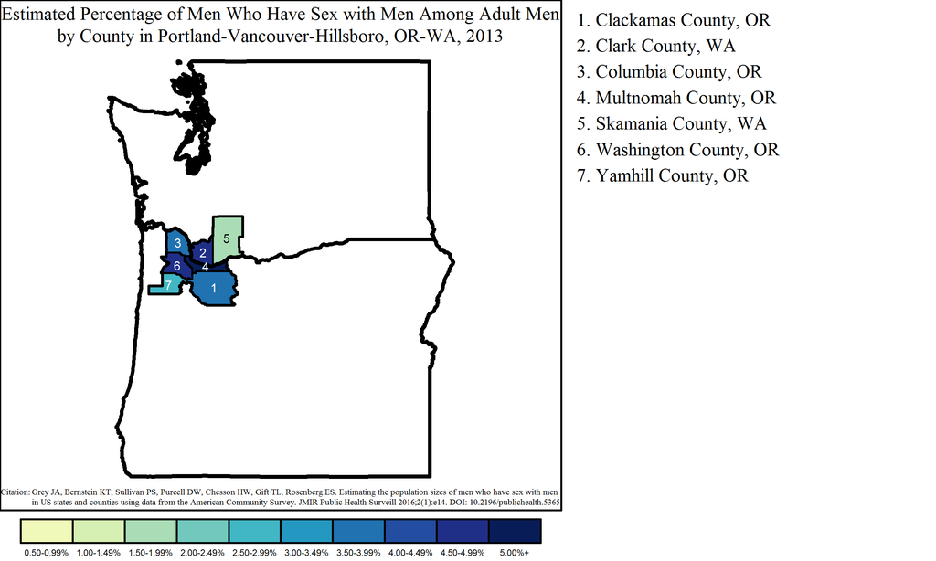

#### Spokane-Spokane Valley Metropolitan Statistical Area

The Spokane-Spokane Valley MSA had a population of 5,020 MSM, or 4.5% of all MSM in Washington. Of the 200,110 adult men in Spokane-Spokane Valley, an estimated 2.5% were MSM.

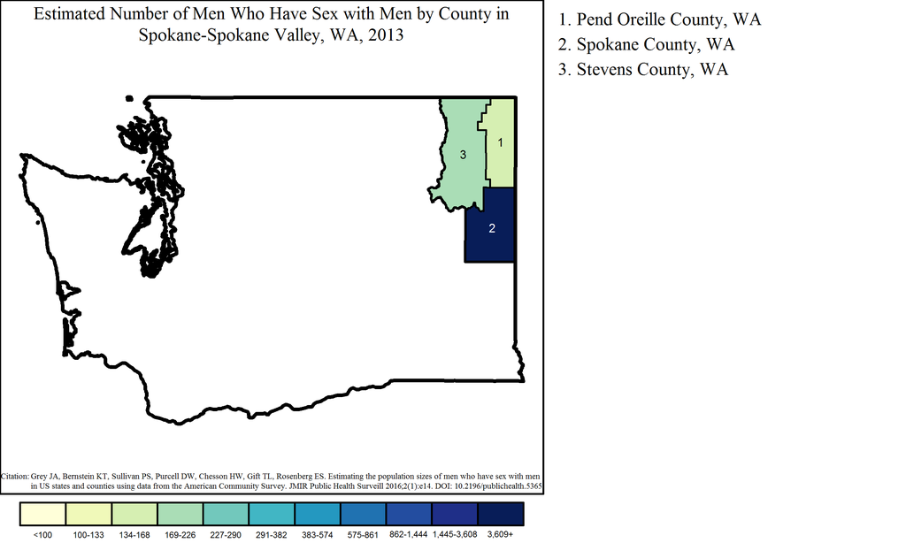

Note: Range cutpoints for the map are based on the distribution of MSM among all counties in the United States.

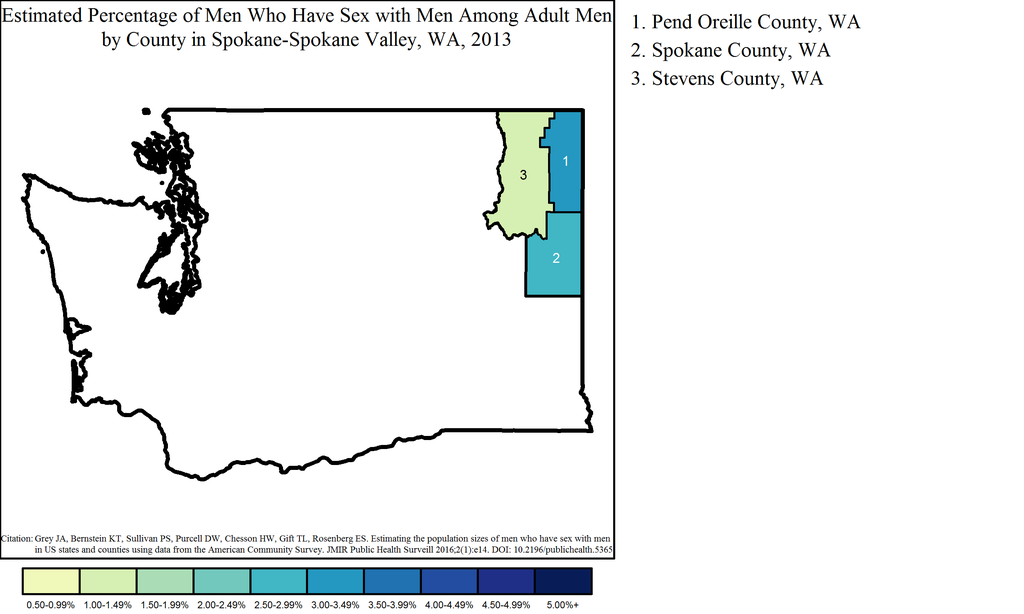

#### Olympia-Tumwater Metropolitan Statistical Area

The Olympia-Tumwater MSA had a population of 2,441 MSM, or 2.2% of all MSM in Washington. Of the 95,045 adult men in Olympia-Tumwater, an estimated 2.6% were MSM.

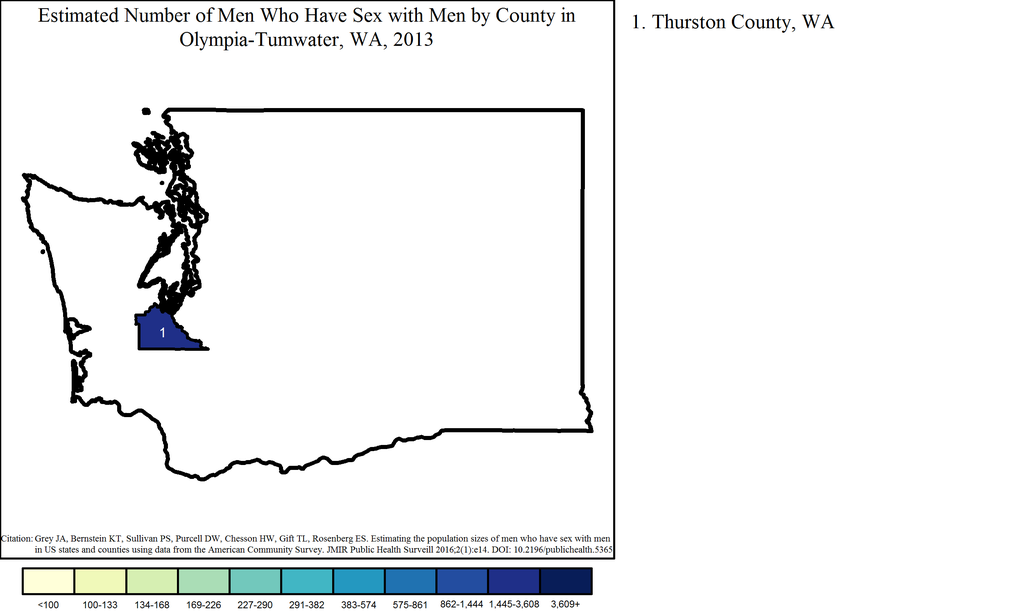

Note: Range cutpoints for the map are based on the distribution of MSM among all counties in the United States.

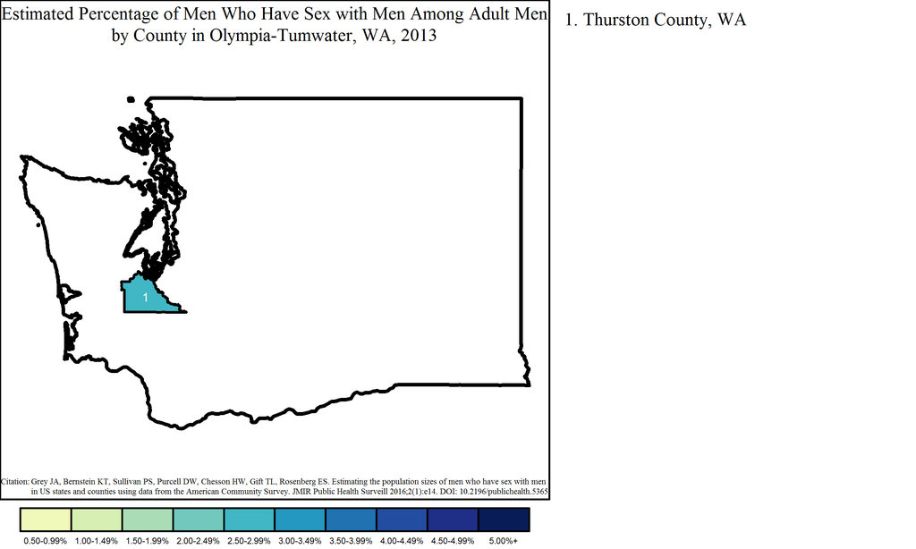

#### Bremerton-Silverdale Metropolitan Statistical Area

The Bremerton-Silverdale MSA had a population of 2,136 MSM, or 1.9% of all MSM in Washington. Of the 99,957 adult men in Bremerton-Silverdale, an estimated 2.1% were MSM.

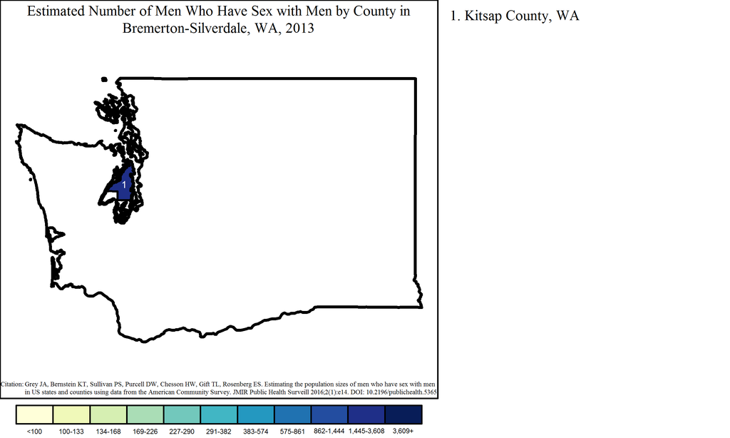

Note: Range cutpoints for the map are based on the distribution of MSM among all counties in the United States.

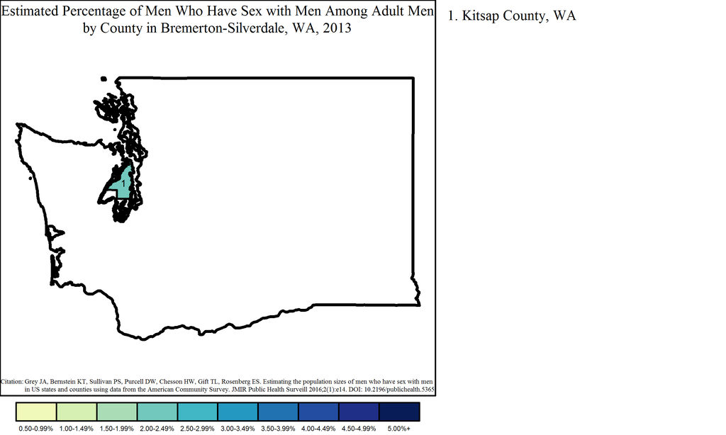

#### Kennewick-Richland Metropolitan Statistical Area

The Kennewick-Richland MSA had a population of 1,775 MSM, or 1.6% of all MSM in Washington. Of the 93,102 adult men in Kennewick-Richland, an estimated 1.9% were MSM.

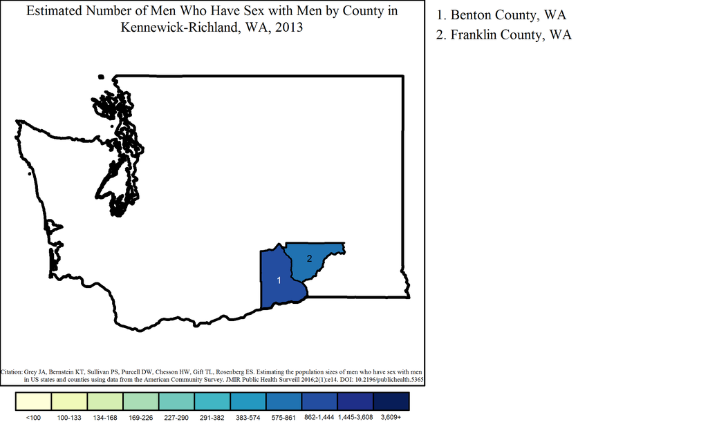

Note: Range cutpoints for the map are based on the distribution of MSM among all counties in the United States.

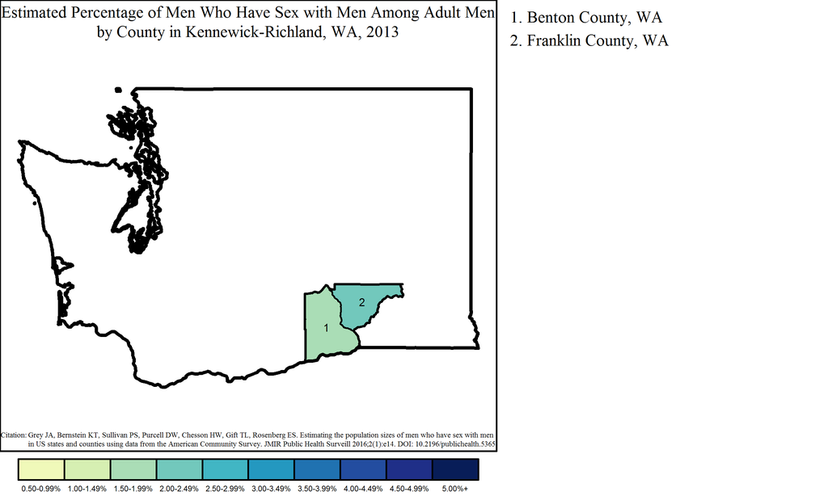

#### Wenatchee Metropolitan Statistical Area

The Wenatchee MSA had a population of 1,536 MSM, or 1.4% of all MSM in Washington. Of the 41,305 adult men in Wenatchee, an estimated 3.7% were MSM.

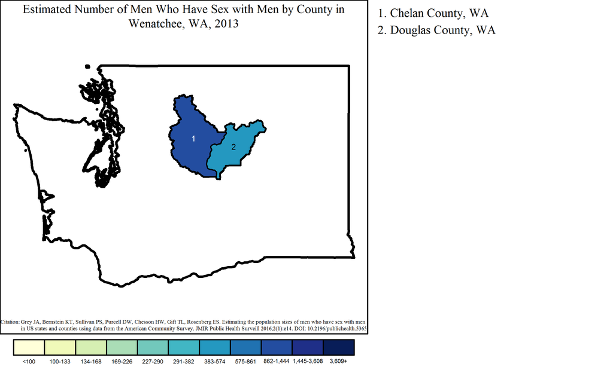

Note: Range cutpoints for the map are based on the distribution of MSM among all counties in the United States.

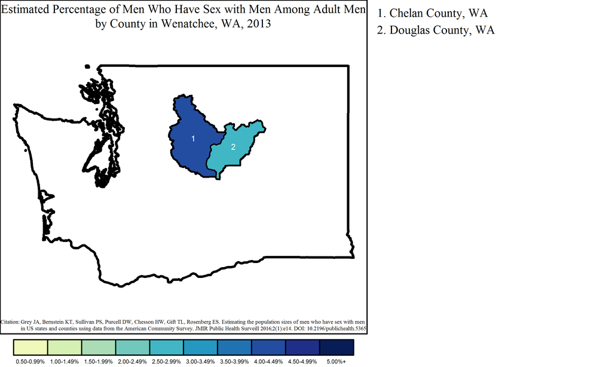

#### Yakima Metropolitan Statistical Area

The Yakima MSA had a population of 1,513 MSM, or 1.4% of all MSM in Washington. Of the 84,722 adult men in Yakima, an estimated 1.8% were MSM.

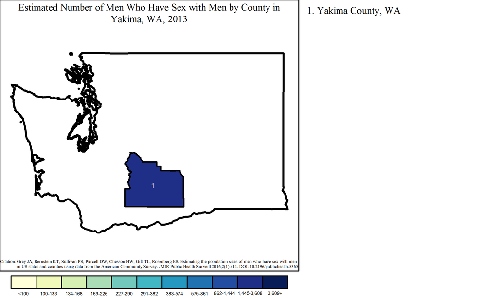

Note: Range cutpoints for the map are based on the distribution of MSM among all counties in the United States.

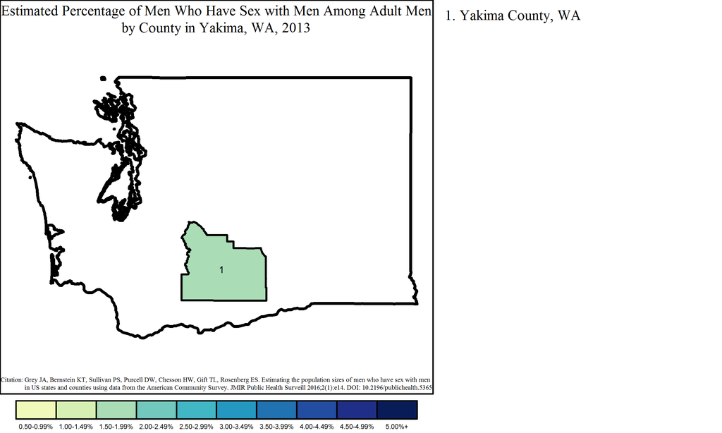

#### Bellingham Metropolitan Statistical Area

The Bellingham MSA had a population of 1,319 MSM, or 1.2% of all MSM in Washington. Of the 79,184 adult men in Bellingham, an estimated 1.7% were MSM.

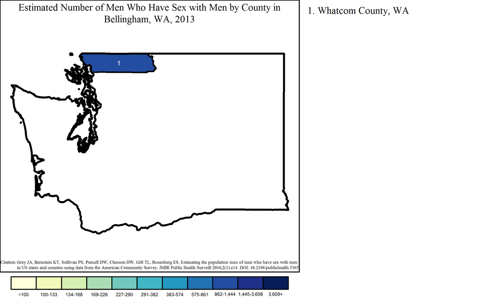

Note: Range cutpoints for the map are based on the distribution of MSM among all counties in the United States.

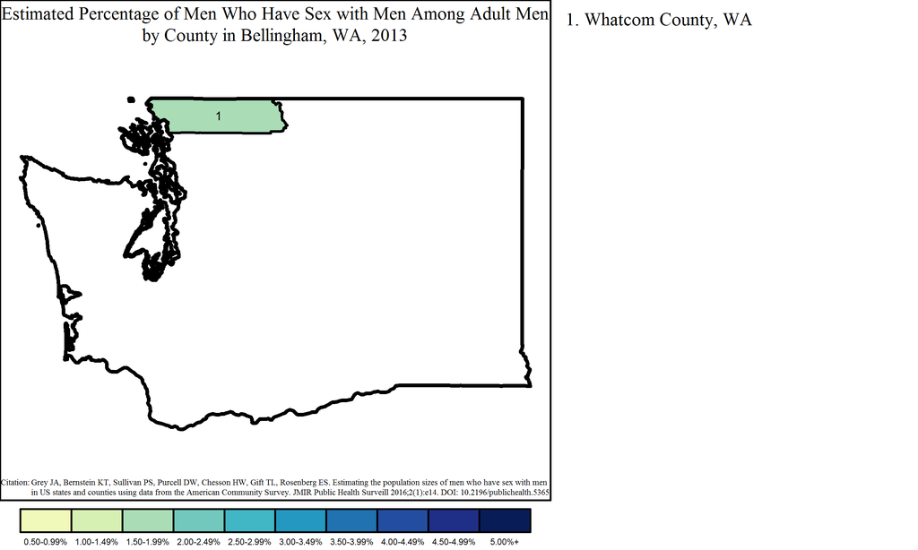

#### Mount Vernon-Anacortes Metropolitan Statistical Area

The Mount Vernon-Anacortes MSA had a population of 632 MSM, or 0.6% of all MSM in Washington. Of the 44,441 adult men in Mount Vernon-Anacortes, an estimated 1.4% were MSM.

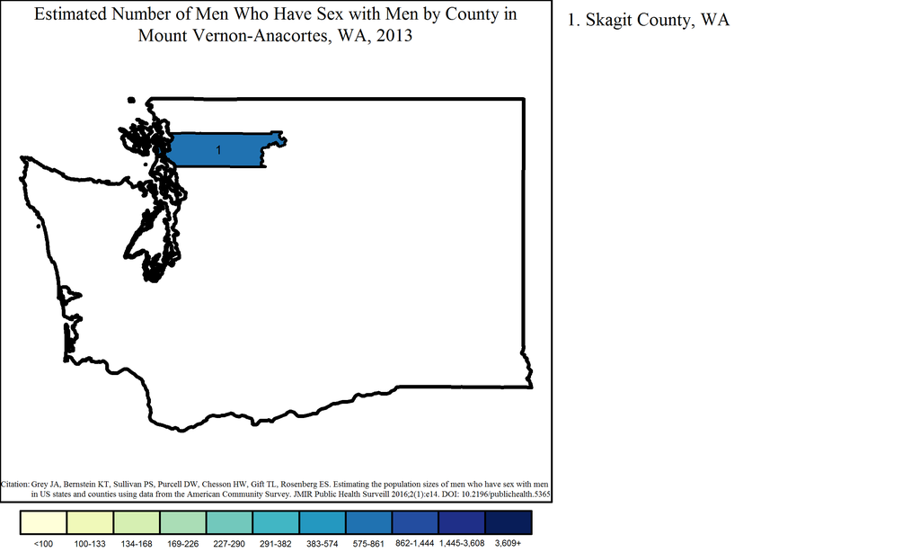

Note: Range cutpoints for the map are based on the distribution of MSM among all counties in the United States.

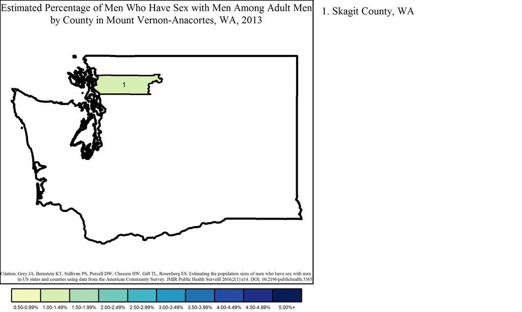

#### Longview Metropolitan Statistical Area

The Longview MSA had a population of 546 MSM, or 0.5% of all MSM in Washington. Of the 38,186 adult men in Longview, an estimated 1.4% were MSM.

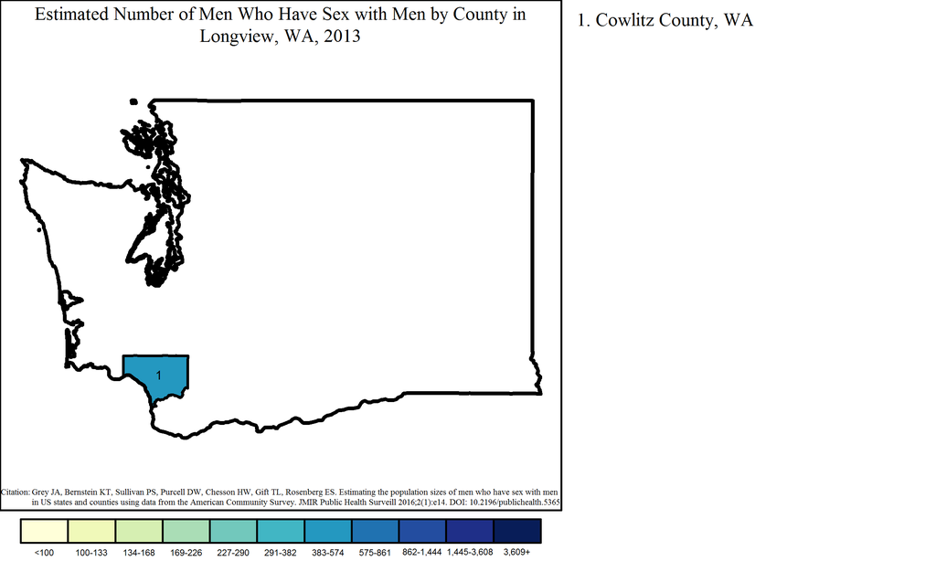

Note: Range cutpoints for the map are based on the distribution of MSM among all counties in the United States.

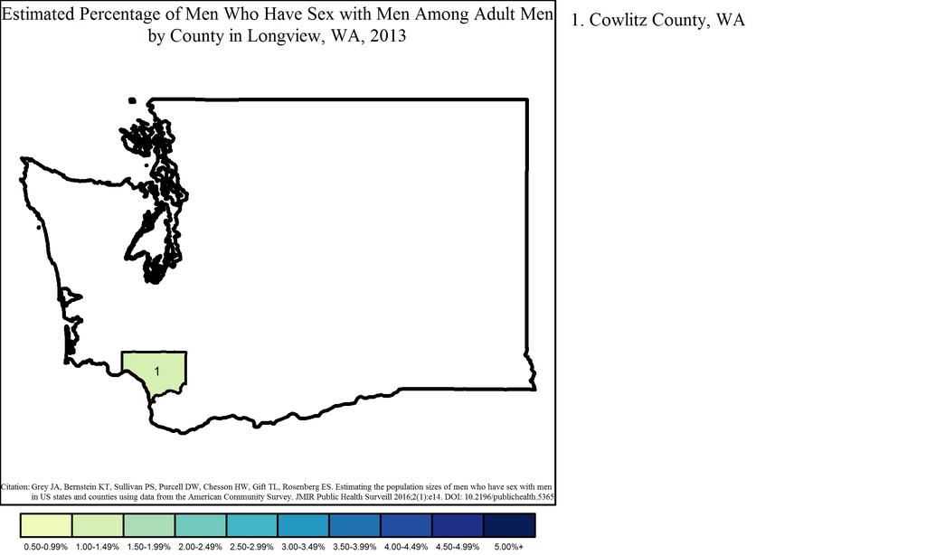

#### Walla Walla Metropolitan Statistical Area

The Walla Walla MSA had a population of 460 MSM, or 0.4% of all MSM in Washington. Of the 25,017 adult men in Walla Walla, an estimated 1.8% were MSM.

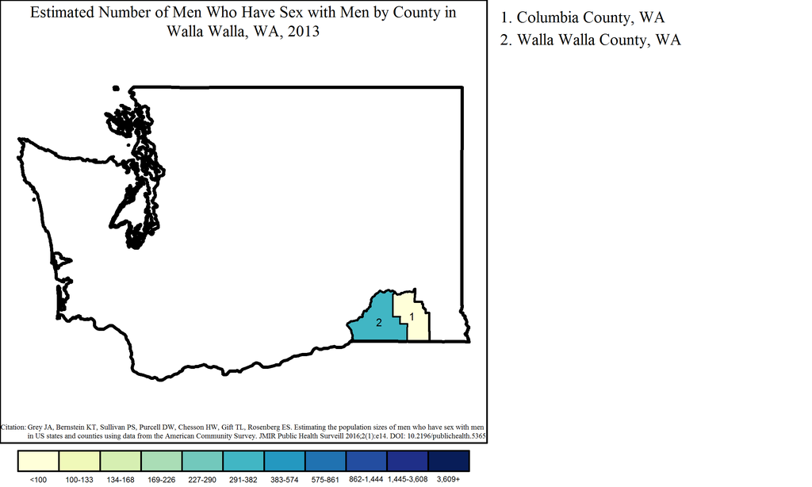

Note: Range cutpoints for the map are based on the distribution of MSM among all counties in the United States.

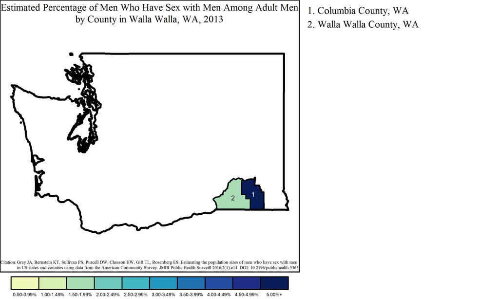

#### Lewiston Metropolitan Statistical Area

The Lewiston MSA overlaps two states: Idaho and Washington. The Washington portion of the MSA had 89 MSM, or 0.1% of all MSM in the state and 23.3% of the 382 MSM in the MSA. Of 8,193 adult men in the Washington part of Lewiston, 1.1% were MSM. This was less than the overall percentage of MSM among adult men in the MSA, which was 1.6% of adult men (382 out of 23,319).

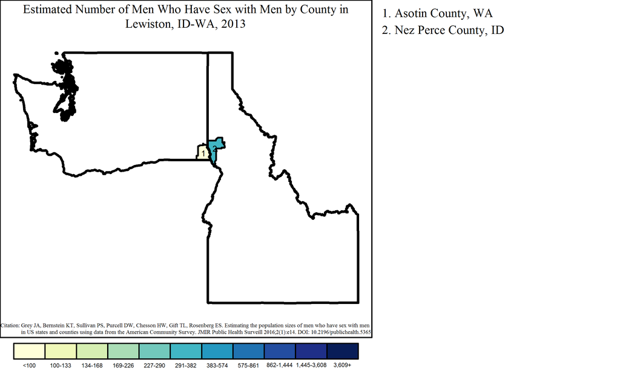

Note: Range cutpoints for the map are based on the distribution of MSM among all counties in the United States.

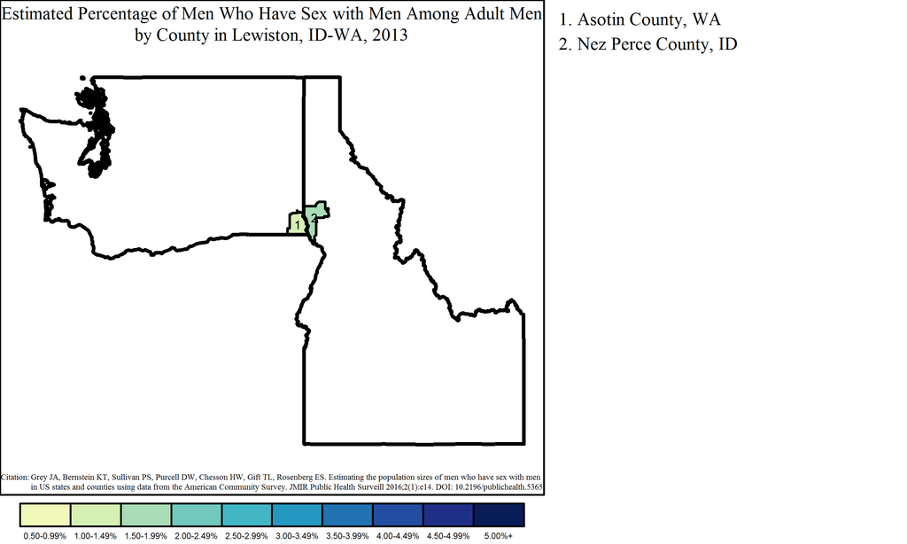